# Case Study 9: Interacting with time

Lorenzo Leme

August 18, 2020

```r
# Use this R-Chunk to import all your datasets!
tickers_today <- c("CXW", "F", "GM", "JCP", "KR", "WDC", "NKE","T", "WDAY", "WFC", "WMT")

cxm1 <- tq_get("CXW", get = "stock.prices")
f1 <- tq_get("F", get = "stock.prices")
gm1 <- tq_get("GM", get = "stock.prices")
jcp1 <- tq_get("JCP", get = "stock.prices")
kro <- tq_get("KR", get = "stock.prices")
wdc1 <- tq_get("WDC", get = "stock.prices")
nke1 <- tq_get("NKE", get = "stock.prices")
t1 <- tq_get("T", get = "stock.prices")
wday1 <- tq_get("WDAY", get = "stock.prices")
wfc1 <- tq_get("WFC", get = "stock.prices")
wmt1 <- tq_get("WMT", get = "stock.prices")

today <- bind_rows(cxm1, f1, gm1, jcp1, kro, wdc1, nke1, t1, wday1, wfc1, wmt1) %>%
   filter(date >= "2015-3-10") %>%
   select(date, volume, close, symbol)
```

## Background

[ ] For your coding development use these tickers - tickers_today <- c(“CXW”, “F”, “GM”, “JCP”, “KR”, “WDC”, “NKE”,“T”, “WDAY”, “WFC”, “WMT”) [ ] Use library(dygraphs) to build interactive visualizations of the stock performances over the last 5 years. [ ] Make a library(ggplot2) graphic that helps you build a solid question around how an investor would use volume in their trading strategy [ ] Create an .Rmd file with 1-2 paragraphs summarizing your graphics and the choices you made in your visualization [ ] Compile your .md and .html file into your git repository [ ] Find two other student’s compiled files in their repository and provide feedback using the issues feature in GitHub (If they already have three issues find a different student to critique) [ ] Address 1-2 of the issues posted on your project and push the updates to GitHub [ ] Publish your case study to Rstudio Connect at shiny.byui.edu

## Data Wrangling

```r
# Use this R-Chunk to clean & wrangle your data!
getSymbols(tickers_today)
```

```
##  [1] "CXW"  "F"    "GM"   "JCP"  "KR"   "WDC"  "NKE"  "T"    "WDAY" "WFC"
## [11] "WMT"
```

```r
closePrices <- do.call(merge, lapply(tickers_today, function(x) Cl(get(x))))
dateWindow <- c("2015-3-10", "2020-3-10")
volume <- do.call(merge, lapply(tickers_today, function(x) Cl(get(x))))

ino <- tq_get("INO", get = "stock.prices")
```

## Data Visualization

```r
# Use this R-Chunk to plot & visualize your data!
dygraph(closePrices, main = "Closing Price Over Five Years", group = "stock") %>%
  dyRangeSelector(dateWindow = dateWindow)
```

[interactive chart not shown]

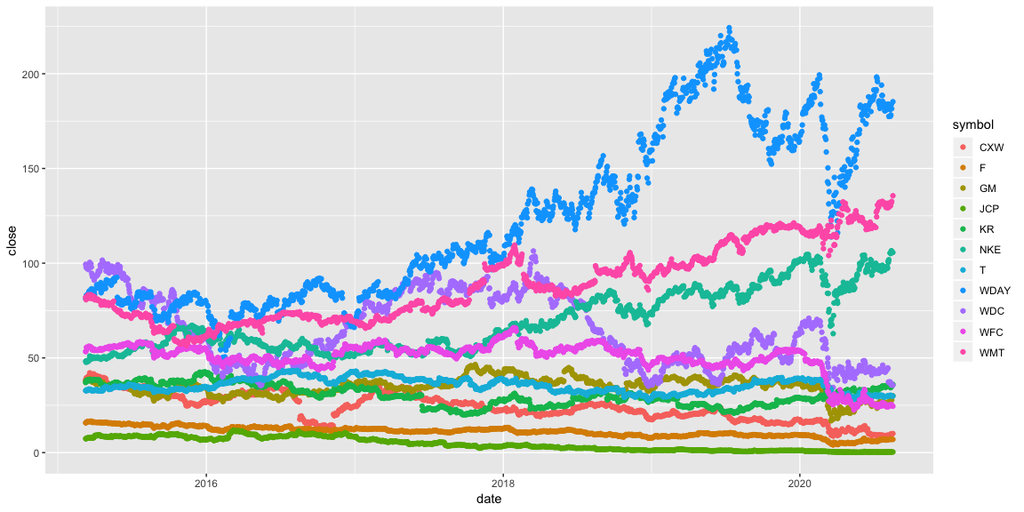

```r
ggplot(today, aes(x=date, color = symbol))+
  geom_point(aes(y=close))
```

### Looking at volumes impact on the stock

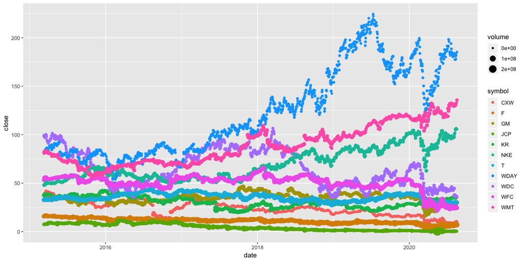

```r
ggplot(today, aes(x=date, color = symbol, size = volume))+
  geom_point(aes(y=close))
```

## Conclusions

If we look at our last plot that implemented stock volume as size we can see that when a stock has a lower volume, the closing price will tend to be higher. This is because there’s not a lot of that particular stock out there, when that happens that can drive the share price upwards.